# part2-model-building-and-selection slides

[figure not shown]

**AI ENTERPRISE WORKFLOW CERTIFICATION**

### Capstone Project - Model Building and Selection

### Data Engineering

- **Engineer Features with Rolling Window**: When forecasting the revenues only the realized (historical) values are known. The unrealized values are not given. Therefore for each instance in the dataset I have to come up with additional features that refer to historical values.
- **Target Value Rolling Window**: To standardize the approach across models ensure the target is the sum of revenues over the next 30 days for any given point in time. For supervised learning, the total revenue over the next thirty days can be represented as a single number

### Model Selection

For each country a model is built and trained. Since the features have different scales, we need to scale the data. The algorithms explored are:

- Stochastic Gradient Descent
- Random Forest Regressor
- Gradient Bossting Regressor
- Ada Boosting Regressor

For each algorithm we used scikit-learn `Pipeline` and `GridSearchCV` to fine tune the hyperparameters and find the optimal model.

**Model Evaluation**

- Cross - Validation score
- Learning curves

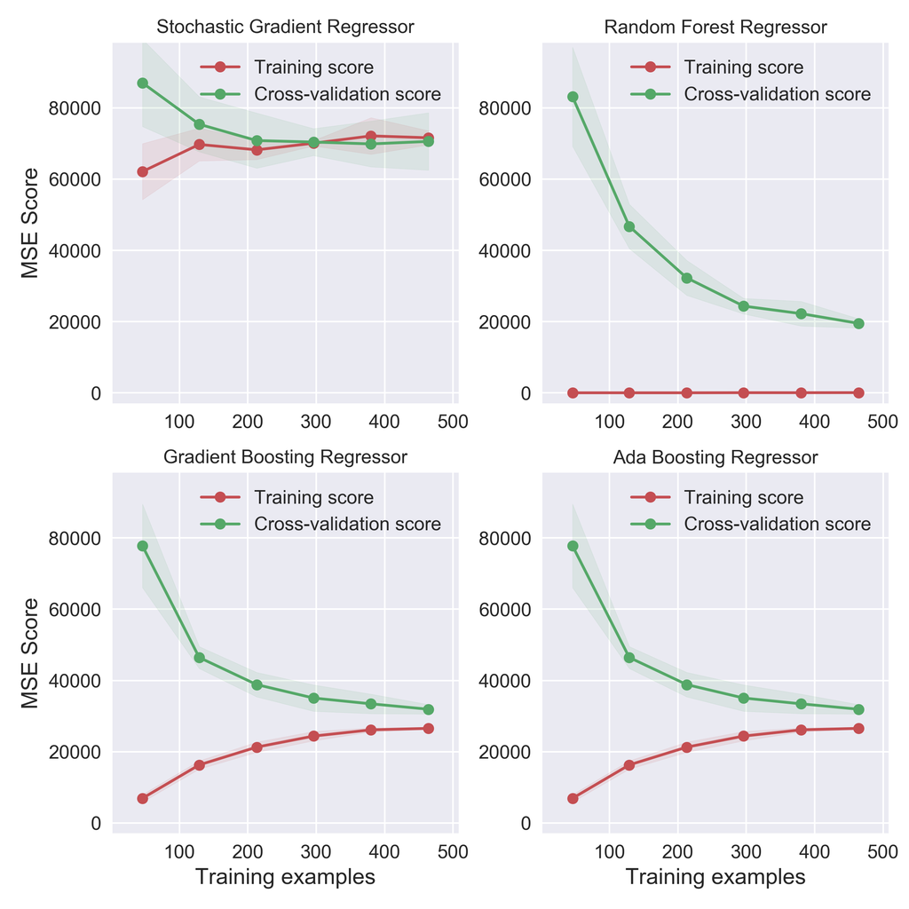

**Model Overview**

|  | model |
| --- | --- |
| EIRE | RandomForestRegressor |
| FRANCE | RandomForestRegressor |
| GERMANY | RandomForestRegressor |
| HONG_KONG | RandomForestRegressor |
| NETHERLANDS | RandomForestRegressor |
| NORWAY | RandomForestRegressor |
| PORTUGAL | RandomForestRegressor |
| SINGAPORE | AdaBoostRegressor |
| SPAIN | RandomForestRegressor |
| TOTAL | RandomForestRegressor |
| UNITED_KINGDOM | RandomForestRegressor |